# D3S Assignment 2

Karnav Popat

25/03/2024

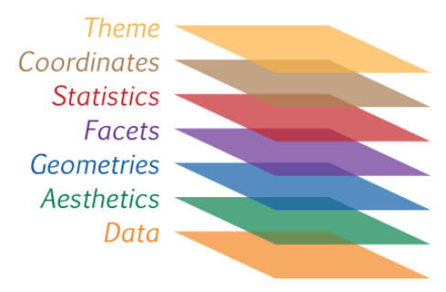

The seven layers of ggplot!

## Question 1

### 1 (a)

The mean number of allopathic hospitals in a district is 18.5. The median is 10.

```r
data <- data%>%
  mutate(total_hospitals=pc11_vd_all_hosp+pc11_td_all_hospital)

summary_stats <- data %>%
  summarize(mean_village_hospitals = mean(pc11_vd_all_hosp, na.rm=TRUE),
            median_village_hospitals = median(pc11_vd_all_hosp, na.rm=TRUE),
            mean_town_hospitals = mean(pc11_td_all_hospital, na.rm=TRUE),
            median_town_hospitals = median(pc11_td_all_hospital, na.rm=TRUE),
            mean_hospitals = mean(total_hospitals, na.rm=TRUE),
            median_hospitals = median(total_hospitals, na.rm=TRUE))%>%
  pivot_longer(cols = everything(), names_to = "Statistic", values_to = "Value")
```

| Statistic | Value |
| --- | --- |
| mean_village_hospitals | 9.821830 |
| median_village_hospitals | 2.000000 |
| mean_town_hospitals | 8.802548 |
| median_town_hospitals | 6.000000 |
| mean_hospitals | 18.540453 |
| median_hospitals | 10.000000 |

### 1 (b)

The mean number of allopathic hospitals per lakh people in a district is 1.27. The median is 0.72.

```r
data <- data%>%
  mutate(vd_hospitals_pp=pc11_vd_all_hosp/(pc11_pca_tot_p/100000))%>%
  mutate(td_hospitals_pp=pc11_td_all_hospital/(pc11_pca_tot_p/100000))%>%
  mutate(total_hospitals_pp=total_hospitals/(pc11_pca_tot_p/100000))

summary_stats_pp <- data %>%
  summarize(mean_village_hospitals_per_person = mean(vd_hospitals_pp, na.rm=TRUE),
            median_village_hospitals_per_person = median(vd_hospitals_pp, na.rm=TRUE),
            mean_town_hospitals_per_person = mean(td_hospitals_pp, na.rm=TRUE),
            median_town_hospitals_per_person = median(td_hospitals_pp, na.rm=TRUE),
            mean_hospitals_per_person = mean(total_hospitals_pp, na.rm=TRUE),
            median_hospitals_per_person = median(total_hospitals_pp, na.rm=TRUE))%>%
  pivot_longer(cols = everything(), names_to = "Statistic", values_to = "Value")
```

| Statistic | Value |
| --- | --- |
| mean_village_hospitals_per_person | 0.7058948 |
| median_village_hospitals_per_person | 0.1104891 |
| mean_town_hospitals_per_person | 0.6101506 |
| median_town_hospitals_per_person | 0.4291007 |
| mean_hospitals_per_person | 1.2660166 |
| median_hospitals_per_person | 0.7204574 |

### 1 (c)

```r
best_district <- data %>%
  select("district_name", "total_hospitals")%>%
  arrange(desc(total_hospitals)) %>%
  slice(1)

best_district_pp <- data %>%
  select("district_name", "total_hospitals_pp")%>%
  arrange(desc(total_hospitals_pp)) %>%
  slice(1)
```

The district with the highest number of allopathic hospitals is Maldah in West Bengal, with 327.

| district_name | total_hospitals |
| --- | --- |
| maldah | 327 |

The district with the highest number of allopathic hospitals per lakh people is Mokokchung in Nagaland, with 16.4.

| district_name | total_hospitals_pp |
| --- | --- |
| mokokchung | 16.44213 |

## Question 2

### 2 (a)

Punjab has the highest % of SC population at the district-level, with a median value of 33%.

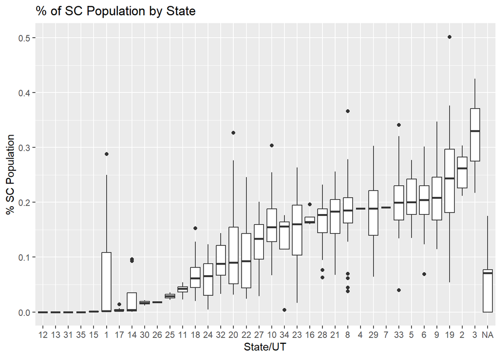

| pc11_state_id | median_sc |
| --- | --- |
| 3 | 0.3303698 |

```r
data <- data%>%
  mutate(sc_percent = pc11_pca_p_sc/pc11_pca_tot_p)

q2a_plot <- data %>%
  group_by(pc11_state_id)%>%
  summarise(median_sc=median(sc_percent), na.rm=TRUE)%>%
  arrange(median_sc)

data["pc11_state_id"] <- factor(data$pc11_state_id, levels = q2a_plot$pc11_state_id)

best_district_sc <- q2a_plot %>%
  select("pc11_state_id", "median_sc")%>%
  arrange(desc(median_sc)) %>%
  slice(1)
```

### 2 (b)

```r
district_shp <- merge(district_shp, data, by.x="pc11_d_id", by.y="pc11_district_id")
```

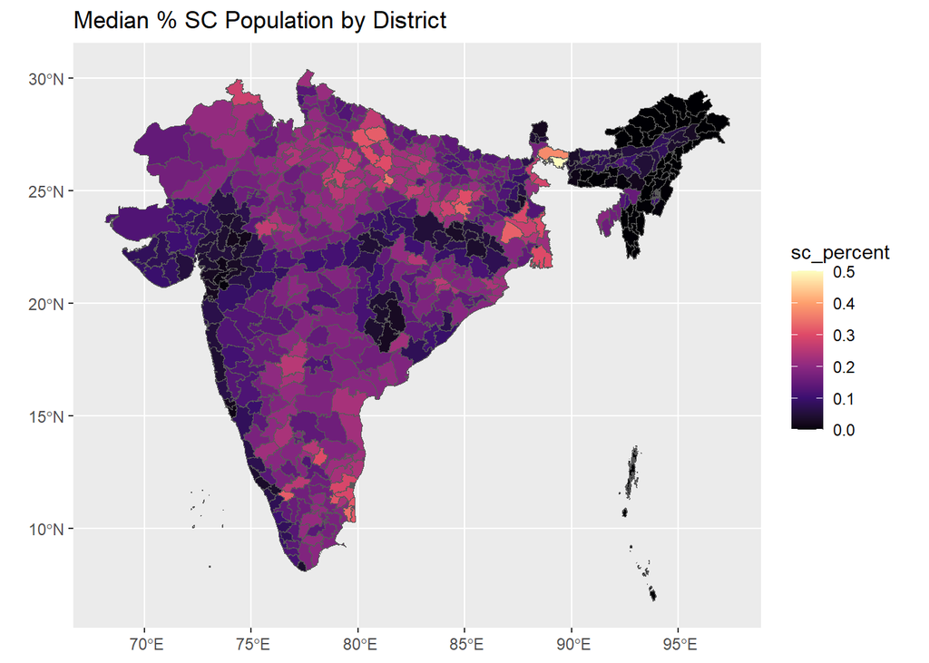

### 2 (c)

Can’t tell without substituting the state IDs for state names. The values seem about right though, with a concentration at 15% or so, the worst states being at less than 10%, and the best being around 33.

### 2 (d)

```r
model <- lm(total_hospitals_pp ~ sc_percent, data = data)
summary(model)
```

```
##
## Call:
## lm(formula = total_hospitals_pp ~ sc_percent, data = data)
##
## Residuals:
##     Min      1Q  Median      3Q     Max
## -1.3851 -0.8696 -0.5561  0.2359 15.0571
##
## Coefficients:
##             Estimate Std. Error t value Pr(>|t|)
## (Intercept)   1.3851     0.1323  10.470   <2e-16 ***
## sc_percent   -0.7940     0.7532  -1.054    0.292
## ---
## Signif. codes:  0 '***' 0.001 '**' 0.01 '*' 0.05 '.' 0.1 ' ' 1
##
## Residual standard error: 1.713 on 616 degrees of freedom
##   (15 observations deleted due to missingness)
## Multiple R-squared:  0.001801,   Adjusted R-squared:  0.0001805
## F-statistic: 1.111 on 1 and 616 DF,  p-value: 0.2922
```

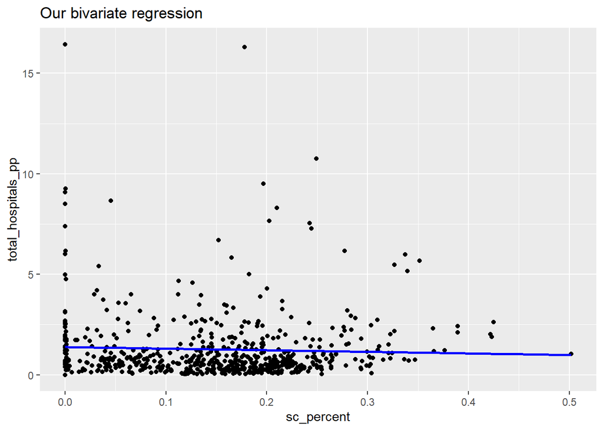

### 2 (f)